# PLS回帰前処理最適化のためのR パッケージ ‘plsropt’

Yasuhiro Uwadaira

2016年6月30日

[version 1.2.0]

## パッケージの概要

Rでpartial least squares regression（PLS回帰）を行う際には[`pls` パッケージ](https://cran.r-project.org/web/packages/pls/index.html)が便利ですが，例えば近赤外分光法などで取得したスペクトルデータを解析する場合，波長範囲や前処理法の違いによって，構築される検量モデルの精度や使用する潜在変数（latent variableあるいはfactor）の数に違いが生じます．

様々な波長範囲や前処理法の組み合わせを網羅的に比較するためには多くの手間と時間を要するため，それらを一括で自動的に実行し，即座に最適な条件を導き出すために開発されたのが`plsropt`パッケージです．

本パッケージ内の`plsrauto`関数は，**任意に指定した変数範囲**および**16パターンの前処理法**を総当りで組み合わせ，全ての条件下でのPLS回帰を`plsr`関数（`pls` パッケージ）を用いて自動的に実行します．

#### 変数範囲

- 任意の範囲をいくつでも指定可能

#### 前処理法（2×4×2×1＝16パターン）

- ステップ1：standard normal variate (SNV) を適用するか否か
- ステップ2：Savitzky-Golay平滑化法，1次微分，2次微分各々を適用するか否か
- ステップ3：標準化（auto-scaling）を適用するか否か
- ステップ4：中心化（mean-centering）は必ず適用されます

#### 結果の出力

PLS回帰によって構築された検量モデルの統計量一覧はCSVファイルとして出力でき，複数のモデルの比較を容易に行うことができます．

また，各モデルの統計量や回帰係数，変数重要度（VIPおよびSelectivity ratio），推定値といった数値データや，結果の解釈に重要なグラフをCSVファイルやPDFファイルとして出力することも可能です．

## はじめに

#### RおよびRStudioがPCにインストールされていない場合

先にRおよびRStudioのインストールを行って下さい．RStudioはRを使う上で非常に便利なツールです．

インストールの方法については，こちらをご参照下さい．手順はとても簡単です．

- [RおよびRStudioのインストール](https://sites.google.com/site/yuwadaira/R-package/installR)

#### 作業ディレクトリの作成

Rでデータ解析を始める前に，作業ディレクトリを準備しておくと便利です．任意の場所にプロジェクト名のディレクトリを作成し，ディレクトリ内にCSV形式のデータを置いておきましょう．

RStudioを起動し，File → New Project → Existing Directoryとクリックしていき，準備しておいた作業ディレクトリを選択します． すると，RStudioのプロジェクトファイル（作業ディレクトリ名.Rproj）及びRのデータファイル（.RData）が作業ディレクトリ内に作成され，RStudio終了時に状態を保存しておけば，次回からはプロジェクトファイルを開くことで解析を再開できます．

## 1. パッケージのインストール

Consoleウィンドウに以下のコマンドを入力し，実行（Enter）します．

なお，File → New File → R Scriptを選択すると，「Untitled1」という名前のファイルが作成されます． ここにコマンドを入力し，実行したいコマンドの行にカーソルを合わせ，「Ctrl + Enter」を押すと，Consoleウィンドウにコマンドが入力され，実行されます． このファイルにコマンドを記入していき，名前を付けて保存しておくと便利です．

```r
# すでに`devtools`パッケージがインストールされている場合、1行目は不要です．
install.packages("devtools")
library(devtools)
install_github("uwadaira/plsropt", dependencies = TRUE)
```

#### パッケージのインストールにエラーが生じる場合

1. 以下のURLにアクセスし，「plsropt_＊＊.tar.gz」という名前のパッケージファイルをダウンロードして下さい．（＊＊部分はバージョン番号）
   - https://github.com/uwadaira/plsropt
2. RStudio起動後，以下のコマンド実行し，必要なパッケージをインストールします．

```r
install.packages("pls")
install.packages("signal")
```

3. RStudioのTools → Install Packages → Install from:でPackage Archive Fileを選択するとエクスプローラーが起動するので，plsropt_**.tar.gzを選択し，Installボタンをクリックして下さい．

## 2. パッケージの読み込み

以下のコマンドを実行し，パッケージを読み込みます．

```r
library(plsropt)
```

`library`はパッケージを読み込むための関数です．**RStudioを再起動したり，セッションをリスタートしたりした場合は，毎回を実行する必要があります**．（他のパッケージを利用する際も同じです）

## 3. データ・セットの準備

### 3.1. サンプルデータの読み込み

このパッケージには，サンプルデータとして`peach`というデータ・セットが付属しています．

`peach`には，サンプル名（`sample`），モモ果汁のBrix糖度（`Brix`），モモ果実の貫入式硬度（`firmness`）および丸ごと果実の近赤外スペクトルデータ（`NIR`）が含まれています．

近赤外スペクトルデータには波長範囲700～2498 nmの吸光度が2 nm毎に記録されています.

`peach`を読み込み，近赤外スペクトルをプロットしてみましょう．

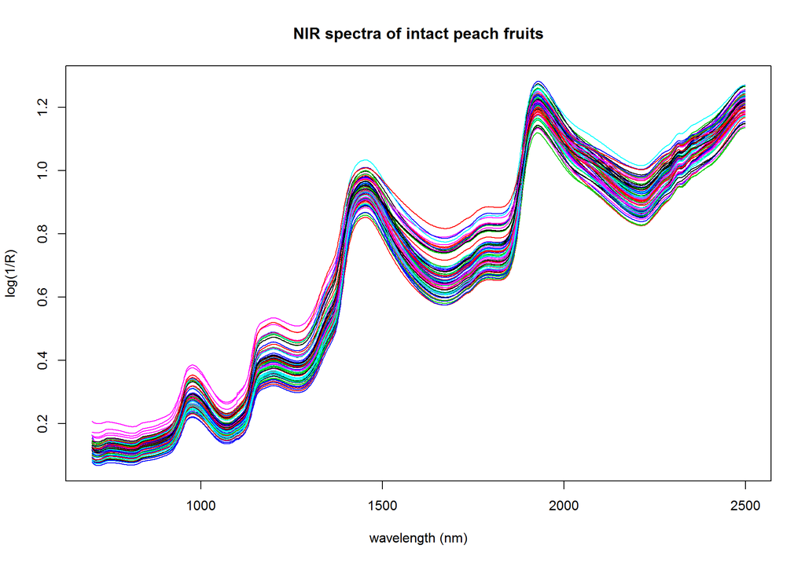

```r
# サンプルデータの読み込み
data(peach)

# 近赤外スペクトルの描画
matplot(colnames(peach$NIR), t(peach$NIR), type = "l", lty = 1,
        xlab = "wavelength (nm)", ylab = "log(1/R)",
        main = "NIR spectra of intact peach fruits")
```

### 3.2. CSVファイルの読み込み

オリジナルのCSVファイルを読み込む場合，**1列目がサンプル名，2列目以降が目的変数（Y変数），説明変数（スペクトルデータ）の順**で並んでいる必要があります．Y変数が複数列あっても問題ありません．

CSVファイルの形式については，[こちら](https://github.com/uwadaira/plsropt)からpeachNIR.csvをダウンロードし，中身をご確認下さい．

作業ディレクトリ内になるCSVファルは，以下のコマンドで読み込むことができます．

```r
# 作業ディレクトリにある"peachNIR.csv"を読み込む
datCSV <- read.csv(file = "peachNIR.csv", row.names = 1, check.names = F)
```

作業ディレクトリが不明な場合は，`getwd`関数で確認して下さい．

```r
# 作業ディレクトリの確認
getwd()
```

`datCSV`はデータフレーム型の変数です．`read.csv`関数で引数`row.names = 1`を指定することで，CSVファイルの1列目のサンプル名は`datCSV`の行名に格納され，`rownames(datCSV)`でアクセスすることができます．列名にアクセスする場合は`colnames(datCSV)`となります．

**行名は必ずサンプル名である必要があります．**

以下のコマンドを実行し，サンプル名が正しく表示されるかどうか確認して下さい．

```r
rownames(datCSV)
```

```
##  [1] "ak01" "ak02" "ak03" "ak04" "ak05" "ak06" "ak07" "ak08" "ak09" "ak10"
## [11] "ak11" "ak12" "ak13" "ak14" "ak15" "ak16" "ak17" "ak18" "ak19" "ak20"
## [21] "ak21" "ak22" "ak23" "ak24" "ak25" "ak26" "ak27" "ak28" "ak29" "ak30"
## [31] "ak31" "ak32" "ak33" "ak34" "ak35" "ak36" "ak37" "ak38" "ak39" "ak40"
## [41] "ak41" "ak42" "ak43" "ak44" "ak45" "ak46" "ak47" "ak48" "ak49" "ak50"
## [51] "ak51" "ak52" "ak53" "ak54" "ak55" "ak56" "ak57" "ak58" "ak59" "ak60"
## [61] "ak61" "ak62" "ak63" "ak64" "ak65" "ak66" "ak67" "ak68" "ak69" "ak70"
## [71] "ak71" "ak72" "ak73" "ak74"
```

もしサンプル名が表示されない場合は，オリジナルCSVファイルの1列目がサンプル名になっていない可能性がありますので，CSVファイルの構成を確認し，CSVファイルをインポートし直して下さい．

各変数には，`datCSV$変数名（列名）`でアクセスすることができます．

ただし，このままではスペクトルデータの波長が一つ一つ独立した形でデータフレームに格納されているため，サンプルデータのように`peach$NIR`といった表記でスペクトルデータ全体にアクセスすることはできません．

そのため，一度スペクトルデータのみを取り出し，それを1つのデータ・セットとして扱えるような形で再度Y変数と結合します．

スペクトルデータは`extdat`関数を使って容易に取り出すことができます．以下のコマンドのように，引数`start`に最初の波長（列名）を，引数`end`に最後の波長を入力します．

```r
# datCSVからX変数を抽出する
x <- extdat(datCSV, start = 700, end = 2498)
```

続いて，再度Y変数と取り出したスペクトルデータを以下のコマンドで結合します．

```r
# Y変数と抽出したX変数を再度結合する

  # Y変数が1つの場合（変数名 = datCSV[, 1]とします）
  peach <- data.frame(Brix = datCSV[, 1], NIR = I(as.matrix(x)))

  # Y変数が複数ある場合
  peach <- data.frame(datCSV[, 1:2], NIR = I(as.matrix(x)))
```

これでサンプルデータ`peach`と同じように，`peach$NIR`で吸光度データにアクセスすることができます．

## 3. PLS回帰

それでは，サンプルデータを用いて，近赤外スペクトルデータからモモ果汁のBrix糖度を推定する検量モデルを作成してみましょう．

波長範囲や前処理法をそれぞれ任意に指定して検量モデルを作成したい場合には，`plsrPlot`関数が便利です．

ここでは例として，波長範囲：700 - 1098 nm，スペクトル前処理：SNV + 2次微分 + Auto-scalingを適用します．

### 3.1. 波長範囲の選択

```r
peach$NIR <- extdat(peach$NIR, start = 700, end = 1098)
```

### 3.2. 前処理法の適用

```r
# SNV
peach$NIR <- snv(peach$NIR)

# Savitzky-Golay２次微分
peach$NIR <- matsgolay(peach$NIR, p = 2, n = 11, m = 2)

# Auto-scaling
peach$NIR <- scale(peach$NIR, center = TRUE, scale = TRUE)
```

`matsgolay`関数を実行すると，Savitzky-Golay平滑化（`m = 0`），1次微分（`m = 1`），2次微分（`m = 2`）処理を適用することができます．引数`p`は平滑化フィルターの次元数，`n`は平滑化ウィンドウサイズ（ポイント数，必ず奇数）です．

### 3.3. PLS回帰の実行

```r
# データ・セットを分割する
datTrain <- peach[1:50, ]
datTest  <- peach[51:74, ]
```

`plsrPlot`関数は`plsr`関数（`pls` パッケージ）を用いてPLS回帰を実行し，モデルの解釈に重要な以下の4つのグラフを描画します.

- クロス・バリデーションにおける潜在変数の数と推定誤差（RMSEP）
- 回帰係数
- 変数重要度（Selectivity ratioおよびVIP）
- 実測値と推定値の散布図

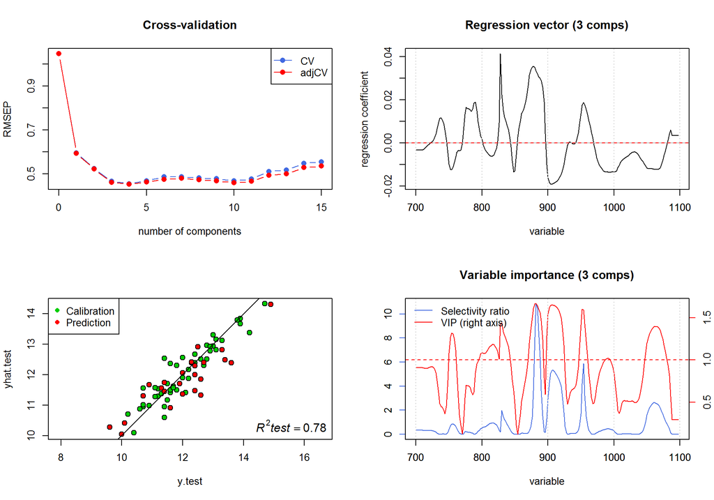

```r
result <- plsrPlot(Brix ~ NIR, data = datTrain, testdata = datTest,
                   ncomp = "auto", maxcomp = 15,
                   validation = "CV", segment.type ="interleaved",
                   output = FALSE)
```

`validation`および`segment.type`は`plsr`関数（`pls`パッケージ）の引数です．`validation = "CV"`および`segment.type ="interleaved"`と指定すると，クロス・バリデーションはVenetian blinds法で実行されます．`validation = "LOO"`とすると`segment.type`は無視され，Leave-one-out法で実行されます．

**`validation`および`segment.type`は必ず指定して下さい．**

セグメント数を指定する場合は`segments`という引数を使います．指定しない場合は10となります．

同じサンプルのスペクトルを3回ずつ測定しているような場合は，`nrep = 3`と指定してください．同じサンプルがトレーニング・セットとバリデーション・セットに分かれず，オーバーフィッティングを防止します．ただし，サンプル順にスペクトルが並んでいる必要があります．

**引数`output = TRUE`を指定すると, 検量モデルの統計量や回帰係数，変数重要度，推定値といった数値データやグラフが“./PLS_result/Brix”内に出力されます．**

`plsr`関数の他の引数も利用できますので，詳細は`pls`パッケージに関する[論文](http://www.jstatsoft.org/article/view/v018i02)あるいは[CRAN](https://cran.r-project.org/web/packages/pls/index.html)のReference manualやVignettesをご参照下さい．

## 4. 最適モデルの探索

波長範囲を短波長領域（700～1098 nm）と長波長領域（1100～2498 nm）の2つに分け，波長範囲と前処理法の最適な組み合わせを探索します．

まず，波長数範囲を`list`型の変数に格納します.

```r
data(peach)

# c()を","で区切って複数入力します
xrange <- list(c(700, 1098), c(1100, 2498))
```

データ・セットをトレーニング・セット（キャリブレーションおよびバリデーション用）とテスト・セット（プレディクション用）に分割します．分割せずに全てのサンプルをトレーニング・セットとして用いる場合は省略可能です．

```r
# データ・セットを分割する
datTrain <- peach[1:50, ]
datTest  <- peach[51:74, ]
```

`plsrauto`関数を実行して，PLS回帰を行います．全てのサンプルをトレーニング・セットとして用いる場合は，引数`data = peach`とし，`testdata = datTest`を削除します．

```r
result.all <- plsrauto(Brix ~ NIR, data = datTrain, maxcomp = 15,
                       testdata = datTest, xrange = xrange,
                       validation = "CV", segment.type ="interleaved")
```

**`plsrauto`関数は，実測値と推定値の相関係数（R）および傾き（Slope），標準誤差（SEC, SECV, SEP），バイアス（Bias），RPD（標準偏差 ÷ 標準誤差）といった検量モデルの統計量一覧を返します．** “.cal”，“.val”，“.test”はそれぞれキャリブレーション・セット，バリデーション・セット，テスト・セットを意味します．

`result.all`はテスト・セットの実測値と推定値の相関係数`R.test`（プレディクションを実行していない場合には`R.val`）で降順にソートされます．

```r
result.all[1:5,]
```

```
##      Xrange                                  Preprocessing  N ncomp
## 1  700-1098 SNV + SG2D(wsize-11pt_forder-2) + Auto-scaling 50     3
## 2 1100-2498 SNV + SG2D(wsize-11pt_forder-2) + Auto-scaling 50     5
## 3 1100-2498                Raw + SG2D(wsize-11pt_forder-2) 50     6
## 4  700-1098 Raw + SGSM(wsize-11pt_forder-2) + Auto-scaling 50    13
## 5 1100-2498                SNV + SG2D(wsize-11pt_forder-2) 50     5
##       R.cal Slope.cal       SEC     R.val Slope.val      SECV
## 1 0.9227512 0.8514698 0.3955816 0.8912028 0.8116926 0.4707582
## 2 0.9380196 0.8798808 0.3557418 0.8669775 0.7512686 0.5167114
## 3 0.9029612 0.8153389 0.4410791 0.7989809 0.6444729 0.6235664
## 4 0.9586762 0.9190601 0.2920183 0.8904772 0.8669100 0.4795906
## 5 0.8898827 0.7918913 0.4682459 0.8007598 0.6346941 0.6211154
##        Bias.val  RPD.val N.test    R.test Slope.test       SEP   Bias.test
## 1  0.0204003408 2.202510     24 0.8848818  0.6682731 0.5904785  0.20186740
## 2 -0.0009736606 2.006632     24 0.8806564  0.5820551 0.6377400  0.07409818
## 3  0.0076535061 1.662773     24 0.8681753  0.7463730 0.6061130 -0.35334664
## 4  0.0380531683 2.161948     24 0.8531950  1.0855430 0.8171300 -0.23097729
## 5 -0.0190375989 1.669335     24 0.8530066  0.7451492 0.6378330 -0.26276194
##   RPD.test
## 1 2.068136
## 2 1.914871
## 3 2.014789
## 4 1.494487
## 5 1.914592
```

実行結果一覧をCSVファイルとして保存したい場合は，以下のコマンドを実行します．Excelで開けば，他の統計量でソートするなどして最適モデルを探索することができます．

```r
# `plsrauto`関数の実行結果をCSV形式で保存する
write.csv(result.all, file = "plsrauto_result.csv")
```

`plsrauto`関数を実行する際，以下のように引数`output = TRUE`を指定すると, `plsrPlot`関数と同様，各検量モデルの統計量や回帰係数，変数重要度，推定値といった数値データやグラフがCSVファイルやPDFファイルとして出力されます．また，実行結果一覧はCSV形式で“./PLS_auto/Brix”内に“result_train.csv”（プレディクションを実行した場合は“result_test.csv”というファイル名で自動的に出力されます．

```r
result.all <- plsrauto(Brix ~ NIR, data = datTrain,
                       testdata = datTest, xrange = xrange,
                       validation = "CV", segment.type ="interleaved",
                       output = TRUE)
```

例えば，波長範囲：**1100～2498 nm**，前処理法：**SNV + SG2D(wsize-11pt_forder-2) + Auto-scaling**の場合には“./PLS_auto/Brix/1100-2498/SNV + SG2D(wsize-11pt_forder-2) + Auto-scaling”内に出力されます．

全てのモデルの結果ファイルは同様に名付けられたディレクトリに自動的に出力されます．